# Case study report for IGF-1

09 July 2022

**Report for: IGF-1 (ukb-d-30770_irnt)**

This case study report includes the results for IGF-1, generated automatically using Rmarkdown.

The report is split into 3(+1) parts:

1. Mendelian randomization (MR) results for IGF-1 for all breast cancer outcomes (BCAC 2017 and 2020)
2. Overview of potential mediators identified from MR-EvE data; their validation with two-step and multivariable MR (MVMR)
3. Overview of potential mediators identified from literature-mined data; their validation with two-step, bidirectional, and MVMR
4. *Optional* validation of results with female-only exposure data (if available)
- Trait IDs in this report correspond to data available in [OpenGWAS](https://gwas.mrcieu.ac.uk/)
- BCAC 2017 outcomes names/IDs: Full sample (“Breast cancer”) `ieu-a-1126`, ER+ sample (“ER+ Breast cancer”)`ieu-a-1127`, ER- sample (“ER- Breast cancer”) `ieu-a-1128`
- MR analyses in this report were performed using TwoSampleMR and MVMR packages
- The two-sample MR estimates presented in this report were produced with inverse-variance weighted (IVW) or Wald ratio (for single SNP traits)

This report is a part of the publication *“Integrating Mendelian randomization and literature-mined evidence for breast cancer risk factors”* Vabistsevits et al 2022

# 1 Main analysis MR results

IGF-1 data details:

- Source: UK Biobank
- Sample size: > 450K
- nSNPs: 318
- Sample sex: mixed

IGF-1 was identified in MR-EvE search as having evidence of effect on breast cancer and validated with IVW MR method in BCAC 2017 and BCAC 2020 breast cancer outcomes:

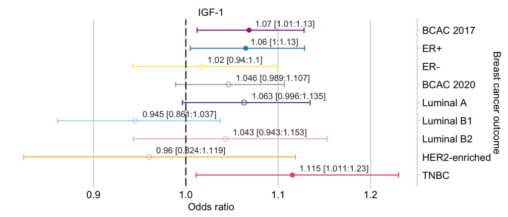

| exposure | outcome | IVW OR | pval | nsnp | Egger intercept < 0.05 | Heterogeneity Qpval < 0.05 |
| --- | --- | --- | --- | --- | --- | --- |
| IGF-1 | BCAC 2017 | 1.07 [1.01:1.13] | 0.017 | 318 | TRUE | TRUE |
| IGF-1 | ER+ | 1.06 [1:1.13] | 0.034 | 318 | TRUE | TRUE |
| IGF-1 | ER- | 1.02 [0.94:1.1] | 0.657 | 318 | TRUE | TRUE |
| IGF-1 | BCAC 2020 | 1.046 [0.989:1.107] | 0.115 | 276 | TRUE | TRUE |
| IGF-1 | Luminal A | 1.063 [0.996:1.135] | 0.065 | 275 | TRUE | TRUE |
| IGF-1 | Luminal B1 | 0.945 [0.861:1.037] | 0.234 | 275 | TRUE | TRUE |
| IGF-1 | Luminal B2 | 1.043 [0.943:1.153] | 0.414 | 275 | TRUE | TRUE |
| IGF-1 | HER2-enriched | 0.96 [0.824:1.119] | 0.603 | 275 | TRUE | TRUE |
| IGF-1 | TNBC | 1.115 [1.011:1.23] | 0.029 | 275 | TRUE | TRUE |

The full MR results and sensitivity analysis are available in Supplementary Data 2 and 3.

# 2 MR-EvE-mined mediators

By querying MR-EvE data for IGF-1 we identified 4 potential mediators. This analysis was done only for BCAC 2017 outcomes (full / ER+ / ER-), and only those that were affected in the main MR analysis: full , ER+ , sample(s)

Below is a table of two-step MR results for each mediator, including *exposure -> mediator* and *mediator -> outcome*. The total effect of *exposure -> outcome* is available in the table above.

## 2.1 Two-step MR

**Full sample**: 2 potential mediators from MR-EvE

| exposure | outcome | mediator.id | mediator | exposure -> mediator (step1) beta_CI | nSNPs (step1) | mediator -> outcome (step2) OR_CI | nSNPs (step2) |
| --- | --- | --- | --- | --- | --- | --- | --- |
| IGF-1 | BCAC 2017 | prot-a-518 | Complement factor B | -0.19 [-0.31:-0.07] | 335 | 1.03 [1:1.06] | 4 |
| IGF-1 | BCAC 2017 | met-c-941 | Mean diameter for VLDL particles | -0.08 [-0.15:-0.01] | 315 | 0.92 [0.88:0.95] | 14 |

**ER+ sample**: 3 potential mediators from MR-EvE

| exposure | outcome | mediator.id | mediator | exposure -> mediator (step1) beta_CI | nSNPs (step1) | mediator -> outcome (step2) OR_CI | nSNPs (step2) |
| --- | --- | --- | --- | --- | --- | --- | --- |
| IGF-1 | ER+ | ukb-b-16881 | Sitting height | 0.1 [0.07:0.14] | 320 | 1.07 [1:1.15] | 550 |
| IGF-1 | ER+ | ukb-a-269 | Impedance of whole body | -0.09 [-0.12:-0.07] | 319 | 1.15 [1.04:1.28] | 333 |
| IGF-1 | ER+ | met-c-941 | Mean diameter for VLDL particles | -0.08 [-0.15:-0.01] | 315 | 0.92 [0.87:0.96] | 14 |

## 2.2 MVMR

Next, we performed MVMR with potential mediators. In the table below, we include the total effect from univariable MR and the direct effect from MVMR accounted for each mediator. The mediator traits that disrupt the total effect are highlighted.

1 traits attenuate the effect of IGF-1 on **breast cancer (full sample)** (highlighted):

| exposure | outcome | mediator | Total effect exposure -> outcome | Exp SNPs (total) | Direct effect exposure -> outcome | Exp SNPs (direct) | Med SNPs (direct) | is_disrupted |
| --- | --- | --- | --- | --- | --- | --- | --- | --- |
| IGF-1 | Breast cancer | Complement factor B | 1.07 [1.01:1.13] | 318 | 1.07 [1.01:1.13] | 311 | 3 | FALSE |
| IGF-1 | Breast cancer | Mean diameter for VLDL particles | 1.07 [1.01:1.13] | 318 | 1.04 [0.99:1.1] | 302 | 17 | TRUE |

3 traits attenuate the effect of IGF-1 on **ER+ breast cancer** (highlighted):

| exposure | outcome | mediator | Total effect exposure -> outcome | Exp SNPs (total) | Direct effect exposure -> outcome | Exp SNPs (direct) | Med SNPs (direct) | is_disrupted |
| --- | --- | --- | --- | --- | --- | --- | --- | --- |
| IGF-1 | ER+ Breast cancer | Sitting height | 1.06 [1:1.13] | 318 | 1.03 [0.98:1.09] | 345 | 610 | TRUE |
| IGF-1 | ER+ Breast cancer | Impedance of whole body | 1.06 [1:1.13] | 318 | 1.06 [0.99:1.12] | 333 | 360 | TRUE |
| IGF-1 | ER+ Breast cancer | Mean diameter for VLDL particles | 1.06 [1:1.13] | 318 | 1.04 [0.98:1.11] | 302 | 17 | TRUE |

# 3 Literature-mined mediators

We searched literature-mined relationships in EpiGraphDB for IGF-1 and breast cancer and used literature-overlap method to identify potential intermediates between the two. The identified intermediates are tested as potential mediaotrs in this section.

## 3.1 Summary

IGF-1 literature space contains:

- 9095 unique triples of terms
- 6609 unique pairs of terms

## 3.2 Literature overlap Sankey plot

This is a Sankey plot of literature overlap between IGF-1 and breast cancer. See the subset versions and explore filters in a separate app: https://mvab.shinyapps.io/literature_overlap_sankey/

[interactive chart not shown]

## 3.3 Matching literature terms to GWAS traits

IGF-1 and breast cancer literature space overlap identified:

- 291 unique literature terms
- 127 terms are available as GWAS traits in OpenGWAS (table below)
- 96 (74 unique) traits have >=1 genome-wide significant SNPs (instruments for MR) (highlighted in the table)

| Literature term | Matching GWAS in OpenGWAS | GWAS ID | nSNPs p < 5x10e8 |
| --- | --- | --- | --- |
| 3 (or 17)-beta-hydroxysteroid dehydrogenase | prot-c-4708_3_2 | 17-beta-HSD 1 | 0 |
| 3 (or 17)-beta-hydroxysteroid dehydrogenase | prot-a-1381 | 17-beta-hydroxysteroid dehydrogenase 14 | 1 |
| 5'-AMP-activated protein kinase | prot-a-2366 | AMP Kinase (alpha2beta2gamma1) | 1 |
| 5'-AMP-activated protein kinase | prot-c-5183_53_3 | AMPK a1b1g1 | 0 |
| 5'-AMP-activated protein kinase | prot-c-5245_40_5 | AMPK a2b2g1 | 0 |
| 5'-AMP-activated protein kinase | prot-a-2365 | AMP Kinase (alpha1beta1gamma1) | 0 |
| Activins | prot-c-2748_3_2 | Activin A | 0 |
| Activins | prot-c-4383_97_1 | Activin AB | 0 |
| Activins | prot-c-2806_49_2 | Activin RIB | 0 |
| Adiponectin | ieu-a-1 | Adiponectin | 14 |
| Adiponectin | prot-c-3554_24_1 | Adiponectin | 0 |
| AKT1 | prot-a-70 | RAC-alpha/beta/gamma serine/threonine-protein kinase | 1 |
| AKT1 | prot-a-71 | RAC-alpha/beta/gamma serine/threonine-protein kinase | 1 |
| Albumin | met-c-841 | Albumin | 3 |
| Albumin | met-d-Albumin | Albumin | 29 |
| Albumin | ukb-d-30600_irnt | Albumin | 203 |
| Albumin | prot-c-3707_12_2 | Albumin | 0 |
| Alkaline Phosphatase | ukb-d-30610_irnt | Alkaline phosphatase | 318 |
| Alkaline Phosphatase | prot-c-2795_23_3 | Alkaline phosphatase, bone | 0 |
| Alkaline Phosphatase | prot-a-81 | Intestinal-type alkaline phosphatase | 2 |
| Alkaline Phosphatase | ebi-a-GCST005061 | Serum alkaline phosphatase levels | 0 |
| arginine | met-a-347 | Arginine | 0 |
| BAX | prot-a-224 | Bcl2-associated agonist of cell death | 1 |
| BCL2-Related Protein 11 | prot-c-4423_77_2 | BCL2-like 1 protein | 0 |
| bone morphogenetic protein 7 | prot-c-2972_57_2 | BMP-7 | 0 |
| bone morphogenetic protein 7 | prot-a-257 | Bone morphogenetic protein 7 | 2 |
| c-myc Genes | prot-a-1978 | Myc proto-oncogene protein | 0 |
| CA2 | prot-c-4970_55_1 | carbonic anhydrase II | 0 |
| CA2 | prot-a-329 | Carbonic anhydrase 2 | 0 |
| Casein Kinase II | prot-a-698 | Casein kinase II 2-alpha':2-beta heterotetramer | 0 |

[output cut: 206 more lines]

## 3.4 Two-step MR (step 2)

We performed two-step MR for 96 traits with >=1 instruments (highlighted in table above):

- 17-beta-hydroxysteroid dehydrogenase 14
- AMP Kinase (alpha2beta2gamma1)
- Adiponectin
- RAC-alpha/beta/gamma serine/threonine-protein kinase
- Albumin
- Alkaline phosphatase
- Intestinal-type alkaline phosphatase
- Bcl2-associated agonist of cell death
- Bone morphogenetic protein 7
- cathepsin D
- CD34 on Hematopoietic Stem Cell
- Hematopoietic progenitor cell antigen CD34
- CD34 on Stem
- Cyclin-dependent kinase inhibitor 1B
- CREB-binding protein
- Crk-like protein
- Cytochrome P450 3A4
- Cytochrome c
- Dynactin-associated protein
- Epidermal growth factor
- EP300-interacting inhibitor of differentiation 3
- Ephrin type-B receptor 2
- Ephrin-B2
- Epiregulin
- Oestradiol
- Estrone 3-sulfate
- Fibroblast growth factor receptor 2
- Follicle stimulating hormone
- Follistatin
- follistatin
- Glycoprotein acetyls
- Glycoproteins
- Guanine nucleotide-binding protein G(k) subunit alpha
- HDL cholesterol
- Histone deacetylase 8
- Human Chorionic Gonadotropin
- Intercellular adhesion molecule 1
- Interferon alpha/beta receptor 1
- Insulin-like growth factor 1 receptor
- Insulin-like growth factor-binding protein 3
- Interleukin-1 beta
- Insulin receptor
- Janus kinase and microtubule-interacting protein 3
- KIT ligand
- Kit ligand
- Leukemia inhibitory factor receptor
- Leukemia inhibitory factor
- Luteinizing hormone
- Mitogen-activated protein kinase 1
- Matrix metalloproteinase-9
- Metallothionein-1F
- Obesity
- Body mass index
- Oxidized low-density lipoprotein receptor 1
- Parathyroid hormone-related protein
- Protein deglycase DJ-1
- Pituitary adenylate cyclase-activating polypeptide
- Urokinase-type plasminogen activator
- Urokinase plasminogen activator surface receptor
- Plasminogen activator inhibitor 1
- Protein kinase C zeta type
- Prolactin receptor
- Proteoglycan 3
- Salivary acidic proline-rich phosphoprotein 1/2
- 26S proteasome non-ATPase regulatory subunit 1
- Protein-tyrosine kinase 2-beta
- Serine/threonine-protein phosphatase 2A 65 kDa regulatory subunit A alpha isoform
- Serine/threonine-protein phosphatase 2A regulatory subunit B’’ subunit alpha
- Tyrosine-protein phosphatase non-receptor type 11
- Sex hormone binding globulin (SHBG)
- SHC-transforming protein 1
- Mothers against decapentaplegic homolog 4
- Mothers against decapentaplegic homolog 2
- Somatostatin-28
- Tumor-associated calcium signal transducer 2
- Bioavailable Testosterone
- Total Testosterone
- Trefoil factor 1
- Tumor necrosis factor
- Transferrin receptor protein 1
- Thioredoxin-interacting protein
- Tyrosine
- Vascular endothelial growth factor receptor 2
- Vascular endothelial growth factor A

Out of these traits, 12 had evidence of effect on breast cancer (so could be considered further as potential mediators):

- HDL cholesterol
- Insulin-like growth factor 1 receptor
- Insulin receptor
- KIT ligand
- Leukemia inhibitory factor receptor
- Body mass index
- Bioavailable Testosterone
- Total Testosterone
- Albumin
- Epidermal growth factor
- Leukemia inhibitory factor
- Vascular endothelial growth factor receptor 2

**Mediator -> outcome (step2) MR results** for the traits with evidence of effect:

| exposure | id.exposure | outcome | OR_CI | nsnp |
| --- | --- | --- | --- | --- |
| HDL cholesterol | met-d-HDL_C | Breast cancer | 1.09 [1.04:1.15] | 82 |
| HDL cholesterol | ieu-b-109 | Breast cancer | 1.09 [1.04:1.15] | 324 |
| Insulin-like growth factor 1 receptor | prot-a-1444 | Breast cancer | 0.82 [0.76:0.88] | 1 |
| Insulin receptor | prot-a-1564 | Breast cancer | 0.94 [0.92:0.97] | 2 |
| KIT ligand | prot-b-20 | Breast cancer | 0.91 [0.84:0.99] | 1 |
| Leukemia inhibitory factor receptor | prot-a-1737 | Breast cancer | 0.87 [0.82:0.91] | 1 |
| Body mass index | ieu-a-974 | Breast cancer | 0.74 [0.64:0.84] | 36 |
| Bioavailable Testosterone | ieu-b-4869 | Breast cancer | 1.12 [1.04:1.2] | 115 |
| Total Testosterone | ieu-b-4864 | Breast cancer | 1.14 [1.06:1.23] | 108 |
| Albumin | met-c-841 | ER+ Breast cancer | 1.21 [1.04:1.41] | 3 |
| Epidermal growth factor | prot-a-908 | ER+ Breast cancer | 0.94 [0.88:0.99] | 1 |
| HDL cholesterol | met-d-HDL_C | ER+ Breast cancer | 1.1 [1.04:1.16] | 82 |
| HDL cholesterol | ieu-b-109 | ER+ Breast cancer | 1.09 [1.03:1.15] | 324 |
| Insulin-like growth factor 1 receptor | prot-a-1444 | ER+ Breast cancer | 0.82 [0.76:0.9] | 1 |
| Insulin receptor | prot-a-1564 | ER+ Breast cancer | 0.94 [0.91:0.96] | 2 |
| KIT ligand | prot-b-20 | ER+ Breast cancer | 0.91 [0.83:1] | 1 |
| Leukemia inhibitory factor receptor | prot-a-1737 | ER+ Breast cancer | 0.87 [0.82:0.92] | 1 |
| Leukemia inhibitory factor | prot-a-1736 | ER+ Breast cancer | 1.1 [1.02:1.18] | 1 |
| Body mass index | ieu-a-974 | ER+ Breast cancer | 0.77 [0.67:0.87] | 36 |
| Bioavailable Testosterone | ieu-b-4869 | ER+ Breast cancer | 1.17 [1.09:1.26] | 115 |
| Total Testosterone | ieu-b-4864 | ER+ Breast cancer | 1.19 [1.09:1.3] | 108 |
| Vascular endothelial growth factor receptor 2 | prot-a-1622 | ER+ Breast cancer | 0.96 [0.93:0.99] | 4 |

## 3.5 Bidirectional MR (exp/med) (step1)

We next performed bidirectional MR to to establish the direction of the effect between the intermediate and the risk factor and identify the traits that are affected by the risk factor (i.e. likely mediator relationship) [**Exposure -> mediator (step1 of two-step MR)**] and the other way around (i.e. potential confounder relationship).

The table below highlights the relationships with evidence of effect.

Potential mediators: **KIT ligand, Bioavailable Testosterone** (traits affect by IGF-1)

| exposure | id.exposure | outcome | id.outcome | beta_CI | effect_direction | nsnp | effect |
| --- | --- | --- | --- | --- | --- | --- | --- |
| IGF-1 | ukb-d-30770_irnt | HDL cholesterol | met-d-HDL_C | 0.01 [-0.02:0.05] | overlaps null | 352 | term trait as mediator |
| HDL cholesterol | met-d-HDL_C | IGF-1 | ukb-d-30770_irnt | 0.01 [-0.04:0.06] | overlaps null | 96 | term trait as confounder |
| IGF-1 | ukb-d-30770_irnt | HDL cholesterol | ieu-b-109 | 0.02 [-0.02:0.05] | overlaps null | 329 | term trait as mediator |
| HDL cholesterol | ieu-b-109 | IGF-1 | ukb-d-30770_irnt | 0.02 [-0.02:0.05] | overlaps null | 341 | term trait as confounder |
| IGF-1 | ukb-d-30770_irnt | Insulin-like growth factor 1 receptor | prot-a-1444 | 0.07 [-0.06:0.19] | overlaps null | 335 | term trait as mediator |
| Insulin-like growth factor 1 receptor | prot-a-1444 | IGF-1 | ukb-d-30770_irnt | -0.04 [-0.07:-0.02] | negative | 1 | term trait as confounder |
| IGF-1 | ukb-d-30770_irnt | Insulin receptor | prot-a-1564 | 0.06 [-0.06:0.18] | overlaps null | 335 | term trait as mediator |
| Insulin receptor | prot-a-1564 | IGF-1 | ukb-d-30770_irnt | -0.01 [-0.03:0] | negative | 2 | term trait as confounder |
| IGF-1 | ukb-d-30770_irnt | KIT ligand | prot-b-20 | 0.21 [0.06:0.36] | positive | 249 | term trait as mediator |
| KIT ligand | prot-b-20 | IGF-1 | ukb-d-30770_irnt | -0.04 [-0.07:-0.01] | negative | 1 | term trait as confounder |
| IGF-1 | ukb-d-30770_irnt | Leukemia inhibitory factor receptor | prot-a-1737 | 0.09 [-0.04:0.21] | overlaps null | 335 | term trait as mediator |
| Leukemia inhibitory factor receptor | prot-a-1737 | IGF-1 | ukb-d-30770_irnt | -0.03 [-0.05:-0.01] | negative | 1 | term trait as confounder |
| IGF-1 | ukb-d-30770_irnt | Body mass index | ieu-a-974 | -0.01 [-0.05:0.03] | overlaps null | 217 | term trait as mediator |
| Body mass index | ieu-a-974 | IGF-1 | ukb-d-30770_irnt | -0.08 [-0.15:-0.01] | negative | 37 | term trait as confounder |
| IGF-1 | ukb-d-30770_irnt | Bioavailable Testosterone | ieu-b-4869 | 0.05 [0.01:0.1] | positive | 328 | term trait as mediator |
| Bioavailable Testosterone | ieu-b-4869 | IGF-1 | ukb-d-30770_irnt | 0.08 [0:0.15] | positive | 122 | term trait as confounder |
| IGF-1 | ukb-d-30770_irnt | Total Testosterone | ieu-b-4864 | 0.02 [0:0.05] | overlaps null | 329 | term trait as mediator |
| Total Testosterone | ieu-b-4864 | IGF-1 | ukb-d-30770_irnt | 0.05 [-0.01:0.12] | overlaps null | 109 | term trait as confounder |
| IGF-1 | ukb-d-30770_irnt | Albumin | met-c-841 | -0.02 [-0.08:0.03] | overlaps null | 315 | term trait as mediator |
| Albumin | met-c-841 | IGF-1 | ukb-d-30770_irnt | -0.04 [-0.08:0.01] | overlaps null | 2 | term trait as confounder |
| IGF-1 | ukb-d-30770_irnt | Epidermal growth factor | prot-a-908 | 0.06 [-0.05:0.18] | overlaps null | 335 | term trait as mediator |
| Epidermal growth factor | prot-a-908 | IGF-1 | ukb-d-30770_irnt | 0.02 [0.01:0.04] | positive | 1 | term trait as confounder |
| IGF-1 | ukb-d-30770_irnt | Leukemia inhibitory factor | prot-a-1736 | 0 [-0.11:0.12] | overlaps null | 335 | term trait as mediator |
| Leukemia inhibitory factor | prot-a-1736 | IGF-1 | ukb-d-30770_irnt | -0.01 [-0.03:0.02] | overlaps null | 1 | term trait as confounder |
| IGF-1 | ukb-d-30770_irnt | Vascular endothelial growth factor receptor 2 | prot-a-1622 | 0.01 [-0.12:0.13] | overlaps null | 335 | term trait as mediator |
| Vascular endothelial growth factor receptor 2 | prot-a-1622 | IGF-1 | ukb-d-30770_irnt | 0 [-0.02:0.02] | overlaps null | 4 | term trait as confounder |

## 3.6 MVMR

For the identified potential mediators we perform MVMR with the known affected outcomes. The table below shows the total effect of exposure (IGF-1) and each mediator, and their direct effects from MVMR analysis together.

The highlighted rows indicate when the direct effect overlaps the null.

[output not shown]

# 4 (Optional): sensitivity analysis with female only data

This section is an optional sensitivity analysis, and is only run where external female-only data is available for the given exposure.

## 4.1 Two-step MR (step 2)

Effect on breast cancer from female-only data of IGF-1

| exposure | outcome | OR_CI | effect_direction | nsnp |
| --- | --- | --- | --- | --- |
| IGF-1 | Breast cancer | 1.08 [1.03:1.15] | positive | 243 |
| IGF-1 | ER+ Breast cancer | 1.09 [1.03:1.16] | positive | 243 |
| IGF-1 | ER- Breast cancer | 1.02 [0.94:1.1] | overlaps null | 243 |

## 4.2 Bidirectional MR (exp/med) (step1) (female-only)

Testing on all literature intermediates and potential mediators from MR-EvE. An empty row indicates that no instruments were available to perform the analysis.

Potential mediators from female-only IGF-1 analysis: Complement factor B, Mean diameter for VLDL particles, Sitting height, Impedance of whole body, Bioavailable Testosterone

| exposure | id.exposure | outcome | id.outcome | beta_CI | effect_direction | nsnp | effect |
| --- | --- | --- | --- | --- | --- | --- | --- |
| IGF | 7T3IO2 | Complement factor B | prot-a-518 | -0.14 [-0.26:-0.01] | negative | 256 | term trait as mediator |
| Complement factor B | prot-a-518 | IGF | 7T3IO2 | -0.01 [-0.05:0.02] | overlaps null | 4 | term trait as confounder |
| IGF | 7T3IO2 | Mean diameter for VLDL particles | met-c-941 | -0.07 [-0.15:0] | negative | 246 | term trait as mediator |
| Mean diameter for VLDL particles | met-c-941 | IGF | 7T3IO2 | -0.09 [-0.2:0.03] | overlaps null | 14 | term trait as confounder |
| IGF | 7T3IO2 | Sitting height | ukb-b-16881 | 0.1 [0.06:0.14] | positive | 248 | term trait as mediator |
| Sitting height | ukb-b-16881 | IGF | 7T3IO2 | 0.02 [-0.03:0.07] | overlaps null | 583 | term trait as confounder |
| IGF | 7T3IO2 | Impedance of whole body | ukb-a-269 | -0.1 [-0.13:-0.08] | negative | 247 | term trait as mediator |
| Impedance of whole body | ukb-a-269 | IGF | 7T3IO2 | -0.04 [-0.11:0.03] | overlaps null | 354 | term trait as confounder |
| IGF | 7T3IO2 | HDL cholesterol | met-d-HDL_C | 0.02 [-0.02:0.05] | overlaps null | 259 | term trait as mediator |
| HDL cholesterol | met-d-HDL_C | IGF | 7T3IO2 | 0 [-0.05:0.05] | overlaps null | 96 | term trait as confounder |
| IGF | 7T3IO2 | HDL cholesterol | ieu-b-109 | 0.02 [-0.01:0.05] | overlaps null | 247 | term trait as mediator |
| HDL cholesterol | ieu-b-109 | IGF | 7T3IO2 | 0.01 [-0.02:0.05] | overlaps null | 346 | term trait as confounder |
| IGF | 7T3IO2 | Insulin-like growth factor 1 receptor | prot-a-1444 | 0 [-0.13:0.13] | overlaps null | 256 | term trait as mediator |
|  |  |  |  |  |  |  | term trait as confounder |
| IGF | 7T3IO2 | Insulin receptor | prot-a-1564 | 0.02 [-0.1:0.13] | overlaps null | 256 | term trait as mediator |
| Insulin receptor | prot-a-1564 | IGF | 7T3IO2 | -0.02 [-0.03:0] | negative | 2 | term trait as confounder |
| IGF | 7T3IO2 | KIT ligand | prot-b-20 | 0.15 [-0.01:0.31] | overlaps null | 189 | term trait as mediator |
|  |  |  |  |  |  |  | term trait as confounder |
| IGF | 7T3IO2 | Leukemia inhibitory factor receptor | prot-a-1737 | 0.02 [-0.1:0.13] | overlaps null | 256 | term trait as mediator |
|  |  |  |  |  |  |  | term trait as confounder |
| IGF | 7T3IO2 | Body mass index | ieu-a-974 | 0.01 [-0.03:0.05] | overlaps null | 172 | term trait as mediator |
| Body mass index | ieu-a-974 | IGF | 7T3IO2 | -0.12 [-0.18:-0.05] | negative | 37 | term trait as confounder |
| IGF | 7T3IO2 | Bioavailable Testosterone | ieu-b-4869 | 0.07 [0.03:0.11] | positive | 247 | term trait as mediator |
| Bioavailable Testosterone | ieu-b-4869 | IGF | 7T3IO2 | 0.14 [0.06:0.21] | positive | 121 | term trait as confounder |
| IGF | 7T3IO2 | Total Testosterone | ieu-b-4864 | 0.02 [-0.01:0.06] | overlaps null | 247 | term trait as mediator |
| Total Testosterone | ieu-b-4864 | IGF | 7T3IO2 | 0.11 [0.04:0.18] | positive | 109 | term trait as confounder |
| IGF | 7T3IO2 | Albumin | met-c-841 | -0.01 [-0.06:0.05] | overlaps null | 246 | term trait as mediator |
| Albumin | met-c-841 | IGF | 7T3IO2 | 0.03 [-0.03:0.09] | overlaps null | 2 | term trait as confounder |
| IGF | 7T3IO2 | Epidermal growth factor | prot-a-908 | 0.09 [-0.03:0.21] | overlaps null | 256 | term trait as mediator |
|  |  |  |  |  |  |  | term trait as confounder |
| IGF | 7T3IO2 | Leukemia inhibitory factor | prot-a-1736 | 0.08 [-0.04:0.19] | overlaps null | 256 | term trait as mediator |
|  |  |  |  |  |  |  | term trait as confounder |
| IGF | 7T3IO2 | Vascular endothelial growth factor receptor 2 | prot-a-1622 | -0.03 [-0.16:0.1] | overlaps null | 256 | term trait as mediator |
| Vascular endothelial growth factor receptor 2 | prot-a-1622 | IGF | 7T3IO2 | 0 [-0.03:0.02] | overlaps null | 4 | term trait as confounder |

## 4.3 MVMR

For the identified potential mediators we perform MVMR with the known affected outcomes. The table below shows the total effect of exposure ( IGF-1 ) and each mediator, and their direct effects from MVMR analysis together.

The highlighted rows indicate when the direct effect overlaps the null.

| # | exposure/mediator | outcome | total effect (MR) | total effect direction | SNPs in total | direct effect (MVMR) | direct effect direction | SNPs in direct |
| --- | --- | --- | --- | --- | --- | --- | --- | --- |
| 1 |  |  |  |  |  |  |  |  |
|  | IGF-1 | Breast cancer | 1.08 [1.03:1.15] | positive | 243 | 1.07 [1.02:1.13] | positive | 247 |
|  | Bioavailable Testosterone | Breast cancer | 1.12 [1.04:1.2] | positive | 115 | 1.12 [1.05:1.2] | positive | 124 |
| 2 |  |  |  |  |  |  |  |  |
|  | IGF-1 | ER+ Breast cancer | 1.09 [1.03:1.16] | positive | 243 | 1.08 [1.02:1.14] | positive | 247 |
|  | Bioavailable Testosterone | ER+ Breast cancer | 1.17 [1.09:1.26] | positive | 115 | 1.17 [1.09:1.26] | positive | 124 |
| 3 |  |  |  |  |  |  |  |  |
|  | IGF-1 | Breast cancer | 1.08 [1.03:1.15] | positive | 243 | 1.08 [1.03:1.15] | positive | 234 |
|  | Mean diameter for VLDL particles | Breast cancer |  |  |  | 0.92 [0.87:0.98] | negative | 15 |
| 4 |  |  |  |  |  |  |  |  |
|  | IGF-1 | ER+ Breast cancer | 1.09 [1.03:1.16] | positive | 243 | 1.09 [1.03:1.16] | positive | 234 |
|  | Mean diameter for VLDL particles | ER+ Breast cancer |  |  |  | 0.92 [0.87:0.98] | negative | 15 |
| 5 |  |  |  |  |  |  |  |  |
|  | IGF-1 | Breast cancer | 1.08 [1.03:1.15] | positive | 243 | 1.09 [1.03:1.15] | positive | 242 |
|  | Complement factor B | Breast cancer |  |  |  | 1.02 [0.98:1.05] | overlaps null | 4 |
| 6 |  |  |  |  |  |  |  |  |
|  | IGF-1 | ER+ Breast cancer | 1.09 [1.03:1.16] | positive | 243 | 1.09 [1.03:1.16] | positive | 242 |
|  | Complement factor B | ER+ Breast cancer |  |  |  | 1.01 [0.97:1.04] | overlaps null | 4 |
| 7 |  |  |  |  |  |  |  |  |
|  | IGF-1 | Breast cancer | 1.08 [1.03:1.15] | positive | 243 | 1.09 [1.03:1.16] | positive | 255 |
|  | Impedance of whole body | Breast cancer |  |  |  | 1.18 [1.08:1.29] | positive | 357 |
| 8 |  |  |  |  |  |  |  |  |
|  | IGF-1 | ER+ Breast cancer | 1.09 [1.03:1.16] | positive | 243 | 1.1 [1.04:1.17] | positive | 255 |
|  | Impedance of whole body | ER+ Breast cancer |  |  |  | 1.16 [1.05:1.27] | positive | 357 |
| 9 |  |  |  |  |  |  |  |  |
|  | IGF-1 | Breast cancer | 1.08 [1.03:1.15] | positive | 243 | 1.08 [1.02:1.13] | positive | 264 |
|  | Sitting height | Breast cancer |  |  |  | 1.07 [1.01:1.13] | positive | 606 |
| 10 |  |  |  |  |  |  |  |  |
|  | IGF-1 | ER+ Breast cancer | 1.09 [1.03:1.16] | positive | 243 | 1.07 [1.02:1.13] | positive | 264 |
|  | Sitting height | ER+ Breast cancer |  |  |  | 1.1 [1.03:1.17] | positive | 606 |